# Math Modelling in Industry Workshop

#### July 31 - August 5, 2017

#### PIMS - University of Manitoba

## Using software tools for the workshop

# Math Modelling - Software tools

We will be using some, or all, of the following tools:

- Basecamp for team work, file sharing, discussions
- Jupyter notebooks, to present text, math, code, visualizations
- Matlab, Python, R, Julia - for coding
- NumPy, SciPy, PyLab, Pandas - tools for scientific computing
- TeX, Beamer, Powerpoint -- for presentations

## Basecamp

Online at http://www.basecamp.com, access via your browser.

Each team has their own project on Basecamp.

You should have received an invitation to log in. (If not, tell Michael.)

Please include your name, and a photo, so your team members can identify you.

Great for sharing files, keep track of progress, recording who does what on the project.

## Jupyter notebook

This presentation is actually a Jupyter notebook.

I like it because it is trivial to include text, images, math formulas and working code in a single document.

Uses the **Markdown** language to do basic typesetting, include images, etc. (google it!)

## Here is some simple math.

```python
# Sum of square reciprocals
(1/1 + 1/4 + 1/9 + 1/16 + 1/25 + 1/36 + 1/49 + 1/64 + 1/81 + 1/100)*2
```

```
3.0995354623330815
```

Looks like that might be approximately $\pi$, but it is not. In fact $$\sum_1^\infty \frac{1}{n^2} = \frac{\pi^2}{6}. $$ Notice that I just threw in a real computation, and a math formula, without even thinking!

With just a bit of work, I can include some Python tools and get plots.

```python
%pylab inline
```

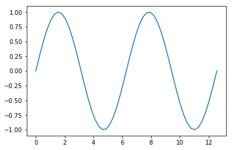

```python
x = linspace(0,4*pi)
y=sin(x)
plot(x,y)
```

## Using Jupyter

- learn about Jupyter at http://jupyter.org/
- use it online at https://pims.syzygy.ca or https://cybera.syzygy.ca (cybera has Julia)
- install it on your laptop, perhaps using Anaconda
- http://intro.syzygy.ca for an eBook on how to use the syzygy service
- https://github.com/mlamoureux for some examples

## Matlab, Python, R, Julia,

- all useful for scientific computation
- Matlab used a lot by mathematicians, esp at universities
- R, RStudio used a lot by statisticians
- Python is used a lot in industry, esp for data science
- NumPy, SciPy, MatPlotLib, Panda are Python extensions for scientific computation
- Julia: new language. Richard Slevinski will talk about it

## Using Matlab, Python, R, Julia

- at UManitoba labs, can access Matlab and R on all machines
- Python, R, Julia available on syzygy.ca
- tryjulia.org to test out Julia
- install on your laptop (Matlab costs money!)

# Presentations

- Powerpoint on all lab machines
- Tex, Beamer only on some lab machines
- For quick and convenient presenations, consider Jupyter notebooks.

## Done.

Questions?

Introduce Slevinski

### Notes to Michael

-- you might need to install MathJax into Chrome or Firefox in order to see the math formulas in .html format.

-- you need to install something in Jupyter in order to get the slide show versions to work.

It's called RISE. Use conda to install it. In the terminal, enter this:

conda install -c damianavila82 rise